# Lab 9: Modeling Data 2

Sonja

10/11/2021

### Objectives

Practice implementing various 1-and 2-sample tests with real data.

#### Q1

The null hypothesis of the Chi-square test is that the observed presence/abundance of the Brown Creeper does not differ from what we would expect if presence/absence was not related to edge/interior habitats.

```
## here() starts at C:/Users/Zonj/Documents/Universites_Research/UMass/courses/ECO 602_634 environ stats/environmental_data
```

```r
chisq.test(br_creeper_table)
```

```
##
##  Pearson's Chi-squared test with Yates' continuity correction
##
## data:  br_creeper_table
## X-squared = 23.3, df = 1, p-value = 1.386e-06
```

#### Q2

Based on the low p value (1.386e-06) we would reject the null hypothesis and state that Brown creepers show significantly different values of observed than the expected. There appears to be a preference of habitat for the Brown Creepers.

#### Q3

```r
fit_species =
  lm(
    formula = body_mass_g~ species,
    data = penguins)
```

#### Q4

```r
fit_sex =
  lm(
    formula = body_mass_g ~ sex,
    data = penguins)
```

#### Q5

```r
fit_both =
  lm(
    formula = body_mass_g~ sex*species,
    data = penguins)
```

#### Q6

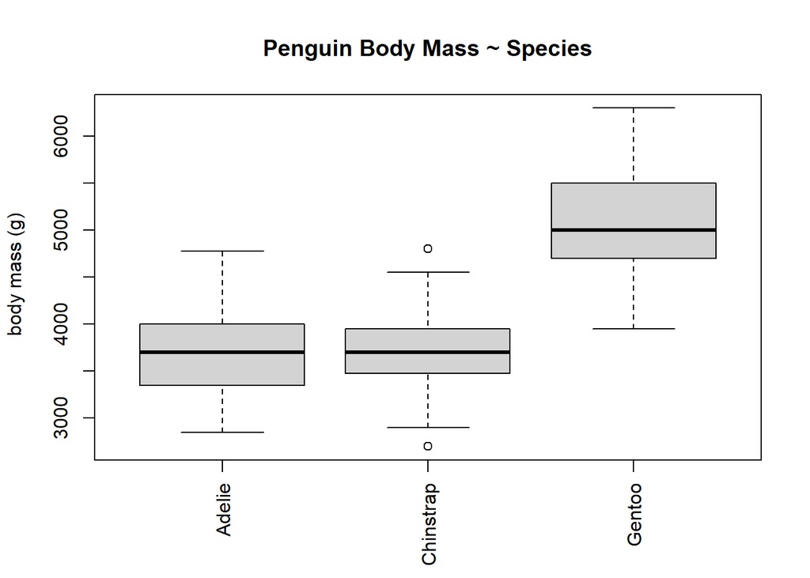

#### Q7

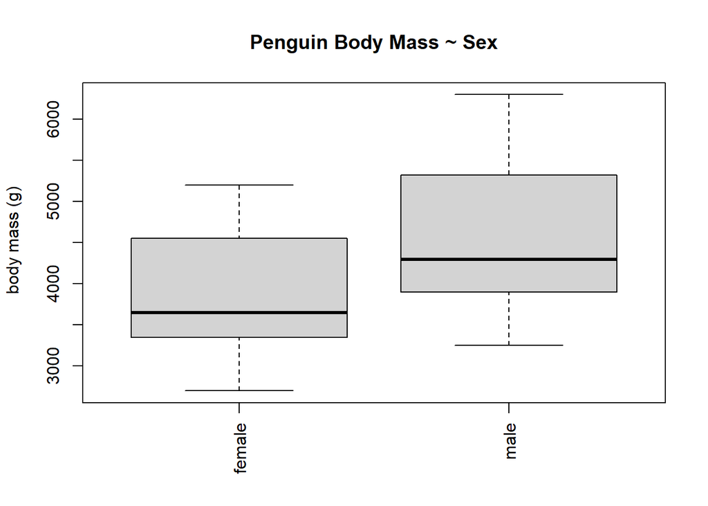

#### Q8

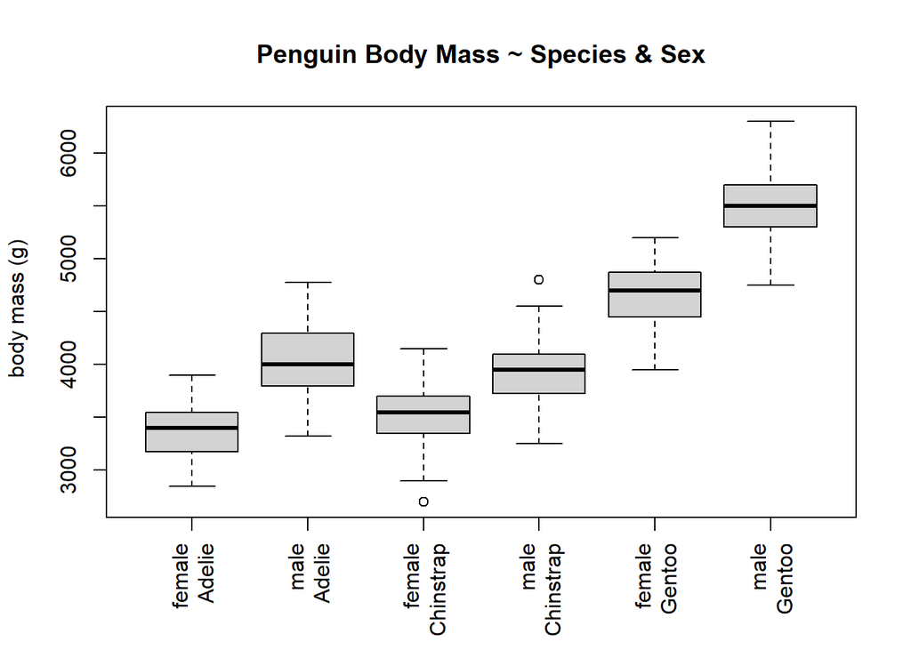

#### Q9

By visually assessing the spread of the data points for the boxplots above, the variation of body mass associated to each category and combination of categories looks pretty homogeneous. Potentially, the boxplot that looks at how penguin species effects body mass might have slightly heterogeneous variation between factors. In this graph Gentoo penguins seems to have slightly more variation than the other two species especially Chinstrap.

#### Q10

The null hypothesis for the Bartlett test is that there is no difference in variance between groups.

#### Q11

p value=0.0501 for the Bartlett test of homogeneity for observations grouped by species.

```r
bartlett.test(body_mass_g~species, data=penguins)
```

```
##
##  Bartlett test of homogeneity of variances
##
## data:  body_mass_g by species
## Bartlett's K-squared = 5.9895, df = 2, p-value = 0.05005
```

#### Q12

p-value = 0.0319 from the Bartlett test of homogeneity for observations grouped by sex.

```r
bartlett.test(body_mass_g~sex, data=penguins)
```

```
##
##  Bartlett test of homogeneity of variances
##
## data:  body_mass_g by sex
## Bartlett's K-squared = 4.6017, df = 1, p-value = 0.03194
```

#### Q13

p-value=0.1741 from the Bartlett test of homogeneity for observations grouped by both factors

```r
dat_groups = aggregate(
  body_mass_g ~ species*sex,
  data = penguins,
  FUN = c)

bartlett.test(dat_groups$body_mass_g, list(dat_groups$species, dat_groups$sex), data=penguins)
```

```
##
##  Bartlett test of homogeneity of variances
##
## data:  dat_groups$body_mass_g
## Bartlett's K-squared = 7.6908, df = 5, p-value = 0.1741
```